# Aprendizaje no supervisado sobre el dataframe

En este notebook se lleva a cabo un análisis no supervisado para dividir en clústeres o subgrafos la red de oncogenes que estamos estudiando. La idea es comparar los datos obtenidos con el aprendizaje no supervisado y el descubrimiento de comunidades. El estudio no supervisado se aplica sobre el dataset generado anteriormente, sin tener en cuenta los campos que funcionan como etiquetas. Se hace uso de dos tipos de clustering: jerárquico y con kmeans.

En primer lugar, cargamos las librerías necesarias.

```r
#install.packages("factoextra")
#install.packages('ggplot2')
library(igraph)
library(readxl)
library(factoextra)
library(dplyr)
```

Cargo el dataframe construido anteriormente. Nos quedamos solo con los atributos que sirven como predictores, los elementos que funcionan como etiqueta no interesan en este paso.

```r
df <- read.table("./grafodf.txt", header = TRUE, sep = ",")
grafodf <- df[, 3:6]
nodos <- df[, 2]
grafodf
```

| Degree | Centrality | Closeness | Betweenness |
| --- | --- | --- | --- |
| 0.5875 | 0.2779780360 | 0.9844992 | 0.0468462952 |
| 0.5500 | 0.1870034906 | 0.9860939 | 0.3733925291 |
| 0.5500 | 0.2773834463 | 0.9851365 | 0.0477648500 |
| 0.5500 | 0.2130654382 | 0.9857746 | 0.5451622780 |
| 0.9375 | 0.9767166663 | 0.9977125 | 0.0000000000 |
| 0.4500 | 0.1554100098 | 0.9825916 | 0.0696570729 |
| 0.4500 | 0.2146015109 | 0.9864134 | 0.1037966932 |
| 0.4375 | 0.4778779212 | 0.9769080 | 0.0000000000 |
| 0.1500 | 0.0382540691 | 0.9586812 | 0.0000000000 |
| 0.5750 | 0.6494478542 | 0.9800583 | 0.0000000000 |

[output cut: 167 more lines]

ALGORITMO K-MEANs

En primer lugar, observamos el valor optimo de k que resulta ser k=3.

```r
fnb<- fviz_nbclust(grafodf, kmeans, method = "silhouette")
fnb$data
```

| clusters | y |
| --- | --- |
| 1 | 0.0000000 |
| 2 | 0.5060658 |
| 3 | 0.6182811 |
| 4 | 0.5243892 |
| 5 | 0.5643926 |
| 6 | 0.5682090 |
| 7 | 0.5714041 |
| 8 | 0.5422959 |
| 9 | 0.5131805 |
| 10 | 0.5413253 |

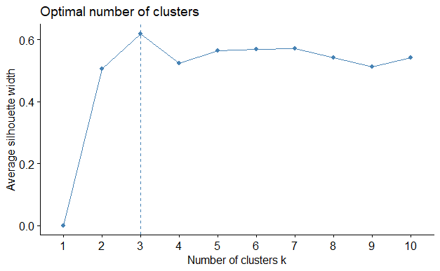

```r
fnb
```

Aplicamos el clustering con kmeans para k=3.

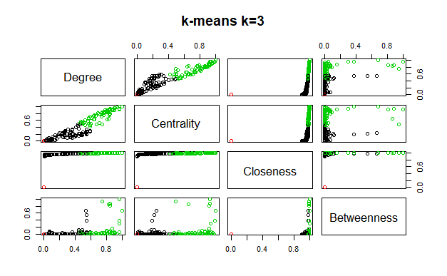

```r
km_grafo <- kmeans(grafodf, centers = 3, nstart = 20)

#visualización
plot(grafodf, col= km_grafo$cluster, main="k-means k=3")
```

Se observan las características del conjunto de datos.

```r
summary(km_grafo)
```

```
             Length Class  Mode
cluster      177    -none- numeric
centers       12    -none- numeric
totss          1    -none- numeric
withinss       3    -none- numeric
tot.withinss   1    -none- numeric
betweenss      1    -none- numeric
size           3    -none- numeric
iter           1    -none- numeric
ifault         1    -none- numeric
```

Se observa cada clúster por separado.

```r
km_clusteres <- km_grafo$cluster
kmclust <- data.frame(nodos, km_clusteres)

c1 <- filter(kmclust, kmclust$km_clusteres == 1)
c1
```

| nodos | km_clusteres |
| --- | --- |
| KRT19 | 1 |
| EPCAM | 1 |
| TACSTD2 | 1 |
| MAL2 | 1 |
| AGR2 | 1 |
| VIM | 1 |
| GJA1 | 1 |
| SRGN | 1 |
| UCHL1 | 1 |
| S100P | 1 |

[output cut: 79 more lines]

```r
c2 <- filter(kmclust, kmclust$km_clusteres == 2)
c2
```

| nodos | km_clusteres |
| --- | --- |
| SPP1 | 2 |
| ALDH1A1 | 2 |
| RPS4Y1 | 2 |
| HSPA1A | 2 |
| PLAC8 | 2 |
| MEST | 2 |
| C3orf14 | 2 |
| LXN | 2 |
| CA2 | 2 |
| CRIP1 | 2 |

[output cut: 8 more lines]

```r
c3 <- filter(kmclust, kmclust$km_clusteres == 3)
c3
```

| nodos | km_clusteres |
| --- | --- |
| TGFBI | 3 |
| IGFBP7 | 3 |
| CAV1 | 3 |
| DKK1 | 3 |
| C19orf33 | 3 |
| SPARC | 3 |
| TFPI2 | 3 |
| CTGF | 3 |
| IGFBP3 | 3 |
| FSTL1 | 3 |

[output cut: 60 more lines]

CLUSTERING JERÁRQUICO

Observamos el numero óptimo de clusters que resulta ser k =4.

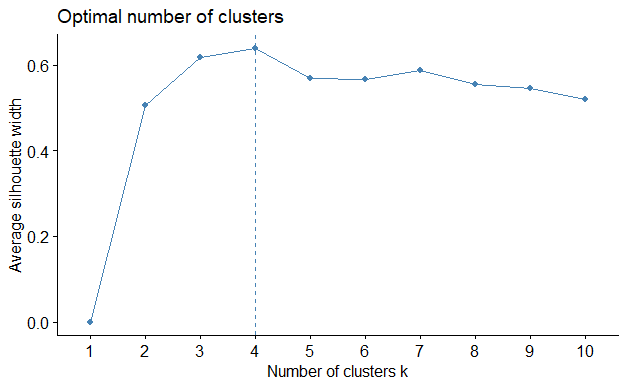

```r
fnv<- fviz_nbclust(grafodf, hcut, method = "silhouette")
fnv
```

```r
fnv$data
```

| clusters | y |
| --- | --- |
| 1 | 0.0000000 |
| 2 | 0.5060658 |
| 3 | 0.6180786 |
| 4 | 0.6382183 |
| 5 | 0.5686768 |
| 6 | 0.5663097 |
| 7 | 0.5879923 |
| 8 | 0.5533983 |
| 9 | 0.5446340 |
| 10 | 0.5205387 |

Obtengo la matriz de distancias y el dendograma.

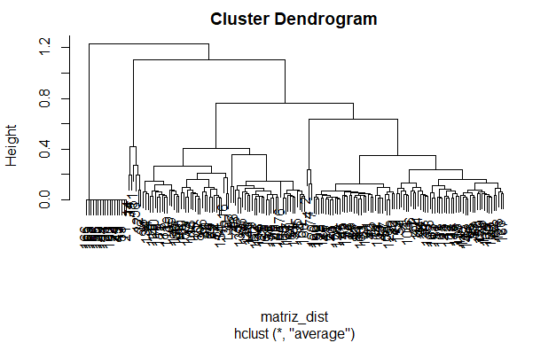

```r
#1- matriz de distancias con dist
matriz_dist <- dist(grafodf)
#2- hclust para construir dendograma
hclust_aux <- hclust(matriz_dist, method = "average")
plot(hclust_aux)
```

Corto el dendograma para k = 4

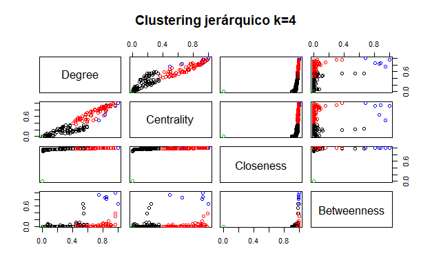

```r
#3- cortar el dendograma y obtener clusters con cutree
grupos1 <- cutree(hclust_aux, k=4)

#represento los resultados
plot(grafodf, col=grupos1, main = "Clustering jerárquico k=4")
```

Se observan las características de los datos generados.

```r
summary(grupos1)
```

```
   Min. 1st Qu.  Median    Mean 3rd Qu.    Max.
  1.000   1.000   2.000   1.695   2.000   4.000
```

Se estudian los clusteres por separado.

```r
hjclust <- data.frame(nodos, grupos1)

c1 <- filter(hjclust, hjclust$grupos1 == 1)
c1
```

| nodos | grupos1 |
| --- | --- |
| KRT19 | 1 |
| EPCAM | 1 |
| TACSTD2 | 1 |
| MAL2 | 1 |
| AGR2 | 1 |
| VIM | 1 |
| SRGN | 1 |
| UCHL1 | 1 |
| S100P | 1 |
| DSP | 1 |

[output cut: 74 more lines]

```r
c2 <- filter(hjclust, hjclust$grupos1 == 2)
c2
```

| nodos | grupos1 |
| --- | --- |
| TGFBI | 2 |
| GJA1 | 2 |
| IGFBP7 | 2 |
| DKK1 | 2 |
| SPARC | 2 |
| TFPI2 | 2 |
| CTGF | 2 |
| IGFBP3 | 2 |
| FSTL1 | 2 |
| ANXA1 | 2 |

[output cut: 59 more lines]

```r
c3 <- filter(hjclust, hjclust$grupos1 == 3)
c3
```

| nodos | grupos1 |
| --- | --- |
| SPP1 | 3 |
| ALDH1A1 | 3 |
| RPS4Y1 | 3 |
| HSPA1A | 3 |
| PLAC8 | 3 |
| MEST | 3 |
| C3orf14 | 3 |
| LXN | 3 |
| CA2 | 3 |
| CRIP1 | 3 |

[output cut: 8 more lines]

```r
c4 <- filter(hjclust, hjclust$grupos1 == 4)
c4
```

| nodos | grupos1 |
| --- | --- |
| CAV1 | 4 |
| C19orf33 | 4 |
| CAV2 | 4 |
| MYOF | 4 |
| GPRC5A | 4 |
| GPX8 | 4 |

COMPARACIÓN DE CLÚSTERES Y COMUNIDADES.

Represento gráficamente las comunidades del descubrimiento de comunidades usando una forma similar para poder comparar con estos resultados. Primero se carga el grafo.

```r
#Cargo datos
aristas <- read_excel("./Dataset1.xlsx",
                    sheet = "WeigthedNetwork")
nodos <- read_excel("./Dataset1.xlsx",
                    sheet = "NetworkNodes")
#Construyo el grafo
grafo_origen <-
  graph_from_data_frame(d = aristas, vertices = nodos,  directed=F)

#Podo cogiendo como umbral 0.4
grafo <- delete_edges(grafo_origen, E(grafo_origen)[PESO<0.4])
```

Se muestran las gráficas.

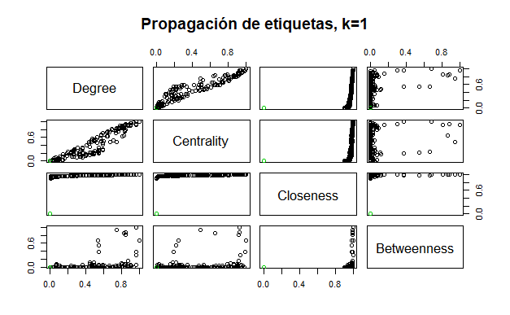

```r
set.seed(55)
inicio<-sample(c(0:176), size = 177, replace = TRUE)
clp <- cluster_label_prop(grafo, initial = inicio, weights = E(grafo))
plot(grafodf, col= clp$membership, main="Propagación de etiquetas, k=1")
```

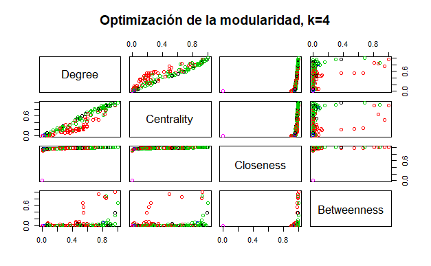

```r
cfg <- cluster_fast_greedy(grafo, weights = E(grafo))
plot(grafodf, col= cfg$membership, main="Optimización de la modularidad, k=4")
```